# Dog breed classification using CNN

Yiming Huang - 22205799

2023-08-14

## Data preparation and generator configuration

- training set: 10 dog breeds with 200 images each
- validation set: 10 dog breeds with 80 images each

```r
# directory of the images
train_dir <- "data/train"
validation_dir <- "data/validation"

# normalize the RGB values from [0-255] into [0-1]
train_datagen <- image_data_generator(rescale = 1/255)
validation_datagen <- image_data_generator(rescale = 1/255)

# set train and validation generator
train_generator <- flow_images_from_directory(
  train_dir,
  train_datagen,
  target_size = c(64, 64),
  batch_size = 20, # 100 batches in total
  class_mode = "categorical"
)
validation_generator <- flow_images_from_directory(
  validation_dir,
  validation_datagen,
  target_size = c(64, 64),
  batch_size = 20, # same batch_size to train_generator, 40 batches in total
  class_mode = "categorical"
)

# set the data augmentation generator
data_augment <- image_data_generator(
  rescale = 1/255,
  width_shift_range = 0.2,
  height_shift_range = 0.2,
  brightness_range = c(0.3, 1),
  shear_range = 0.2,
  zoom_range = 0.2,
  horizontal_flip = TRUE,
  fill_mode = "nearest"
)

# train data generator with data augmentation
train_generator_aug <- flow_images_from_directory(
  train_dir,
  data_augment,
  target_size = c(64, 64),
  batch_size = 20, # same batch_size to train_generator
  class_mode = "categorical"
)
```

## Model training and validation

```r
# deploy a convolutional neural network with data augmentation
model <- keras_model_sequential() %>%
  # convolutional layers
  layer_conv_2d(filters = 32, kernel_size = c(3, 3), activation = "relu",
                input_shape = c(64, 64, 3)) %>%
  layer_max_pooling_2d(pool_size = c(2, 2)) %>%
  layer_conv_2d(filters = 64, kernel_size = c(3, 3), activation = "relu") %>%
  layer_max_pooling_2d(pool_size = c(2, 2)) %>%
  layer_conv_2d(filters = 64, kernel_size = c(3, 3), activation = "relu") %>%
  layer_max_pooling_2d(pool_size = c(2, 2)) %>%
  # fully connected layers
  layer_flatten() %>%
  layer_dense(units = 64, activation = "relu") %>%
  layer_dense(units = 10, activation = "softmax") %>%
  # compile
  compile(
    loss = "categorical_crossentropy",
    metrics = "accuracy",
    optimizer = optimizer_adam()
  )

# fit the CNN model with data augmentation
fit <- model %>% fit(
  train_generator_aug,
  steps_per_epoch = 100,
  epochs = 100,
  validation_data = validation_generator,
  validation_steps = 40, # no more than the batches of validation_generator
  verbose = 0
)
```

## Training and predictive performance visualization

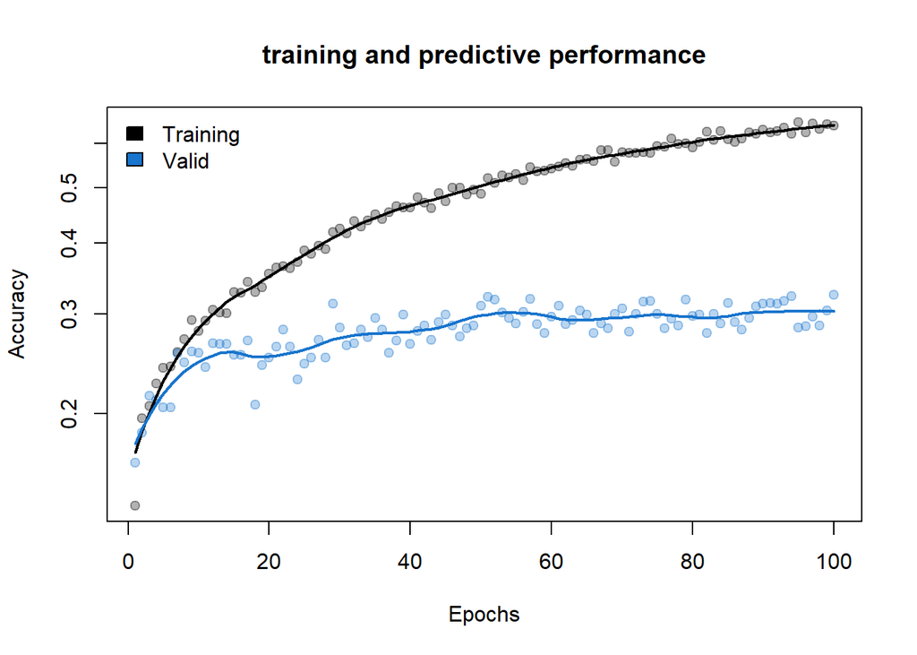

```r
# check accuracy and loss learning curve
out <- cbind(fit$metrics$accuracy,
                 fit$metrics$val_accuracy,
                 fit$metrics$loss,
                 fit$metrics$val_loss)
cols <- c("black", "dodgerblue3", "darkorchid4", "magenta")
# accuracy plot
matplot(out[,1:2],
        pch = 19, ylab = "Accuracy", xlab = "Epochs",
        col = adjustcolor(cols[1:2], 0.3),
        log = "y")
title("training and predictive performance")
# to add a smooth line to points
smooth_line <- function(y, span = 0.3) {
  x <- 1:length(y)
  out <- predict( loess(y ~ x, span = span) )
  return(out)
}
matlines(apply(out[,1:2], 2, smooth_line), lty = 1, col = cols[1:2], lwd = 2)
legend("topleft",
       legend = c("Training", "Valid"),
       fill = cols[1:2], bty = "n")
```

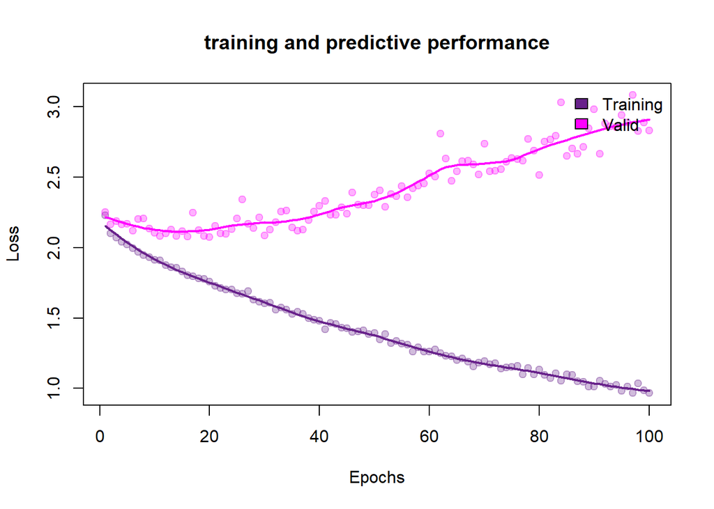

```r
# loss plot
matplot(out[,3:4], pch = 19, ylab = "Loss", xlab = "Epochs",
        col = adjustcolor(cols[3:4], 0.3))
title("training and predictive performance")
matlines(apply(out[,3:4], 2, smooth_line), lty = 1, col = cols[3:4], lwd = 2)
legend("topright",
       legend = c("Training", "Valid"),
       fill = cols[3:4], bty = "n")
```

As the epochs increases, the gap between the training curve and validation curve becomes larger, indicating overfitting.

The accuracy of validation (around 0.3) is not high, but we can have a look at the testing performance later.

## Testing performance

- testing set: 10 dog breeds with 40 images each

```r
# directory of the images
test_dir <- "data/test"
# normalize the RGB values from [0-255] into [0-1]
test_datagen <- image_data_generator(rescale = 1/255)
# set test generator
test_generator <- flow_images_from_directory(
  test_dir,
  test_datagen,
  target_size = c(64, 64),
  batch_size = 20,
  class_mode = "categorical"
)
# to convert image to array
image_prep <- function(x) {
  arrays <- lapply(x, function(path) {
    img <- image_load(path, target_size = c(64, 64),
                      grayscale = F # Set FALSE if image is RGB
    )
    x <- image_to_array(img)
    x <- array_reshape(x, c(1, dim(x)))
    x <- x/255 # rescale image pixel
  })
  do.call(abind::abind, c(arrays, list(along = 1)))
}
# convert image to array
x_test <- image_prep(test_generator$filepaths)
# one-hot encoding of target variable
y_test <- to_categorical(test_generator$labels)
# test performance
model %>% evaluate(x_test, y_test, verbose = 0)
```

```
##     loss accuracy
## 2.684857 0.370000
```

```r
# actual and predicted class labels
class_labels <- names(test_generator$class_indices) %>%
  gsub("_", " ", .) %>% str_to_title()
class_y <- class_labels[max.col(y_test)] # actual class labels
class_hat_idx <- model %>% predict( x_test, verbose = 0) %>% max.col()
class_hat <- class_labels[class_hat_idx] # predicted class labels
```

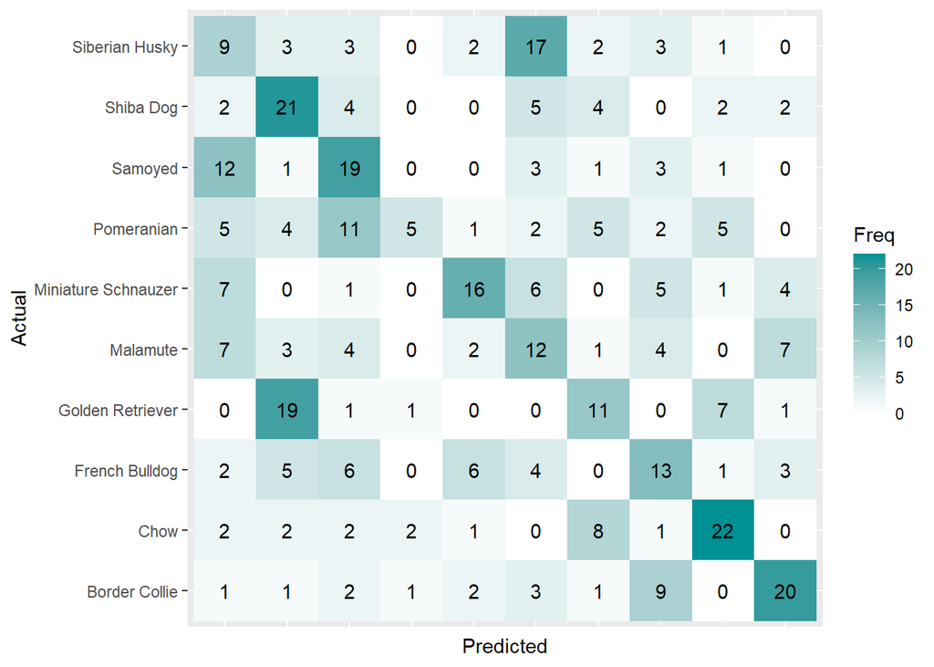

```r
# Confusion Matrix
tab <- as.matrix(table(Actual = class_y, Predicted = class_hat))
plt <- as.data.frame(tab)
plt$Predicted <- factor(plt$Predicted, levels=rev(levels(plt$Predicted)))
class_labels_ordered <- sort(class_labels)
ggplot(plt, aes(Predicted,Actual, fill= Freq)) +
  geom_tile() + geom_text(aes(label=Freq)) +
  scale_fill_gradient(low="white", high="#009194") +
  labs(x = "Predicted",y = "Actual") +
  scale_y_discrete(labels=class_labels_ordered) +
  theme(axis.text.x=element_blank(),
        axis.ticks.x=element_blank()
  )
```

Most of the cells in the primary diagonal (number of correct recognitions) have higher values.

Most of the cells not in the primary diagonal (number of incorrect recognitions) have lower values.

```r
# overall accuracy
accuracy <- sum(diag(tab))/sum(tab)
accuracy
```

```
## [1] 0.37
```

```r
# precision
precision <- diag(tab)/colSums(tab)
# class-specific accuracy (recall)
recall <- diag(tab)/rowSums(tab)
# F-1 score
f1 = 2 * precision * recall / (precision + recall)
data.frame(precision, recall, f1)
```

```
##                     precision recall        f1
## Border Collie       0.5405405  0.500 0.5194805
## Chow                0.5500000  0.550 0.5500000
## French Bulldog      0.3250000  0.325 0.3250000
## Golden Retriever    0.3333333  0.275 0.3013699
## Malamute            0.2307692  0.300 0.2608696
## Miniature Schnauzer 0.5333333  0.400 0.4571429
## Pomeranian          0.5555556  0.125 0.2040816
## Samoyed             0.3584906  0.475 0.4086022
## Shiba Dog           0.3559322  0.525 0.4242424
## Siberian Husky      0.1914894  0.225 0.2068966
```

```r
# average auc score
auc <- multiclass.roc(class_y, class_hat_idx)
auc$auc
```

```
## Multi-class area under the curve: 0.6571
```

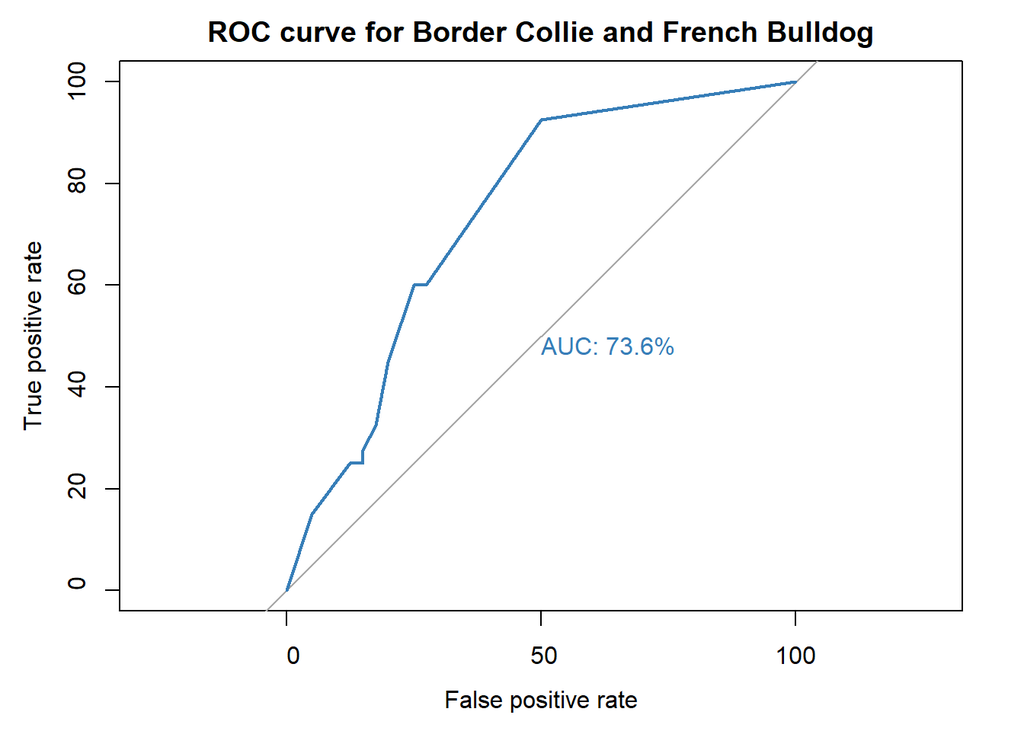

```
##
## Call:
## roc.default(response = class_y, predictor = class_hat_idx, levels = c("Border Collie",     "French Bulldog"), percent = TRUE, plot = TRUE, legacy.axes = TRUE,     main = "ROC curve for Border Collie and French Bulldog",     xlab = "False positive rate", ylab = "True positive rate",     col = "#37…
##
## Data: class_hat_idx in 40 controls (class_y Border Collie) < 40 cases (class_y French Bulldog).
## Area under the curve: 73.62%
```

```r
# roc curve
roc(class_y, class_hat_idx, plot = TRUE, legacy.axes = TRUE,
               levels=c('Border Collie', 'French Bulldog'), percent = TRUE,
    main = "ROC curve for Border Collie and French Bulldog",
    xlab = "False positive rate",
    ylab = "True positive rate", col = "#377eb8", lwd = 2,
    print.auc = TRUE)
```

```r
# find the 1st, 2nd and 3rd most likely class
ranks <- t( apply(tab, 1, function(x) {
  class_labels_ordered[ order(x, decreasing = TRUE)[1:3]] } ) ) %>%
  as.data.frame() %>% setNames(c("1st", "2nd", "3rd"))
ranks
```

```
##                                     1st                 2nd              3rd
## Border Collie             Border Collie      French Bulldog         Malamute
## Chow                               Chow    Golden Retriever       Pomeranian
## French Bulldog           French Bulldog Miniature Schnauzer          Samoyed
## Golden Retriever              Shiba Dog    Golden Retriever             Chow
## Malamute                       Malamute       Border Collie   Siberian Husky
## Miniature Schnauzer Miniature Schnauzer      Siberian Husky         Malamute
## Pomeranian                      Samoyed                Chow Golden Retriever
## Samoyed                         Samoyed      Siberian Husky   French Bulldog
## Shiba Dog                     Shiba Dog            Malamute Golden Retriever
## Siberian Husky                 Malamute      Siberian Husky   French Bulldog
```

We can see that most dogs correctly matched their first most likely class.

The mismatch of ‘Pomeranian’ is most likely due to the similarity of coat colour between it and other dog breeds like ‘Samoyed’. Although we know a Pomeranian is much smaller than a Samoyed, because there is only one dog in an image, the machine can not distinguish which is smaller or larger. Similar to the mismatch of ‘Golden Retriever’.

However, ‘Malamute’ and ‘Siberian Husky’ are supposed to be very similar breeds. Most people have trouble telling the difference, let alone the machine. It is a great challenge for the model to classify the two dog breeds correctly.